# DS Workflow for HP +10 ML Algorithms +12 Plot

## 4- Inputs & Outputs

For every machine learning problem, you should ask yourself, what are inputs and outputs for the model?

[figure not shown]

### 4-1 Inputs

- train.csv - the training set
- test.csv - the test set

### 4-2 Outputs

- sale prices for every record in test.csv

## 5 Loading Packages

In this kernel we are using the following packages:

[figure not shown]

### 5-1 Import

```python
from sklearn.linear_model import Ridge, RidgeCV, ElasticNet, LassoCV, LassoLarsCV
from sklearn.base import BaseEstimator, TransformerMixin, RegressorMixin, clone
from sklearn.linear_model import ElasticNet, Lasso,  BayesianRidge, LassoLarsIC
from sklearn.ensemble import RandomForestRegressor,  GradientBoostingRegressor
from sklearn.model_selection import KFold, cross_val_score, train_test_split
from sklearn.metrics import make_scorer, accuracy_score
from sklearn.ensemble import RandomForestClassifier
from sklearn.model_selection import cross_val_score
from sklearn.metrics import classification_report
from sklearn.model_selection import GridSearchCV
from sklearn.preprocessing import StandardScaler
from sklearn.metrics import mean_squared_error
from sklearn.preprocessing import RobustScaler
from sklearn.metrics import confusion_matrix
from sklearn.kernel_ridge import KernelRidge
from sklearn.pipeline import make_pipeline
from sklearn.metrics import accuracy_score
from sklearn.pipeline import Pipeline
import matplotlib.pyplot as plt
from scipy.stats import skew
import scipy.stats as stats
import lightgbm as lgb
import seaborn as sns
import xgboost as xgb
import pandas as pd
import numpy as np
import matplotlib
import warnings
import sklearn
import scipy
import json
import sys
import csv
import os
```

### 5-2 Version

```python
print('matplotlib: {}'.format(matplotlib.__version__))
print('sklearn: {}'.format(sklearn.__version__))
print('scipy: {}'.format(scipy.__version__))
print('seaborn: {}'.format(sns.__version__))
print('pandas: {}'.format(pd.__version__))
print('numpy: {}'.format(np.__version__))
print('Python: {}'.format(sys.version))
```

```
matplotlib: 2.2.3
sklearn: 0.20.2
scipy: 1.1.0
seaborn: 0.9.0
pandas: 0.23.4
numpy: 1.15.4
Python: 3.6.6 |Anaconda, Inc.| (default, Oct  9 2018, 12:34:16)
[GCC 7.3.0]
```

### 5-5-3 Setup

A few tiny adjustments for better **code readability**

```python
pd.set_option('display.float_format', lambda x: '%.3f' % x)
sns.set(style='white', context='notebook', palette='deep')
warnings.filterwarnings('ignore')
sns.set_style('white')
%matplotlib inline
```

## 6- Exploratory Data Analysis(EDA)

In this section, you'll learn how to use graphical and numerical techniques to begin uncovering the structure of your data.

1. Which variables suggest interesting relationships?
2. Which observations are unusual?

By the end of the section, you'll be able to answer these questions and more, while generating graphics that are both insightful and beautiful. then We will review analytical and statistical operations:

1. Data Collection
2. Visualization
3. Data Cleaning
4. Data Preprocessing

[figure not shown]

## 6-1 Data Collection

**Data collection** is the process of gathering and measuring data, information or any variables of interest in a standardized and established manner that enables the collector to answer or test hypothesis and evaluate outcomes of the particular collection.[techopedia]

> **<< Note >>**

> **The rows being the samples and the columns being attributes**

```python
# import Dataset to play with it
train = pd.read_csv('../input/train.csv')
test= pd.read_csv('../input/test.csv')
```

The **concat** function does all of the heavy lifting of performing concatenation operations along an axis. Let us create all_data.

```python
all_data = pd.concat((train.loc[:,'MSSubClass':'SaleCondition'],
                      test.loc[:,'MSSubClass':'SaleCondition']))
```

**<< Note 1 >>**

1. Each row is an observation (also known as : sample, example, instance, record)
2. Each column is a feature (also known as: Predictor, attribute, Independent Variable, input, regressor, Covariate)

After loading the data via **pandas**, we should checkout what the content is, description and via the following:

```python
type(train),type(test)
```

```
(pandas.core.frame.DataFrame, pandas.core.frame.DataFrame)
```

## 6-1-1 Statistical Summary

1- Dimensions of the dataset.

2- Peek at the data itself.

3- Statistical summary of all attributes.

4- Breakdown of the data by the class variable.[7]

Don’t worry, each look at the data is **one command**. These are useful commands that you can use again and again on future projects.

```python
# shape
print(train.shape)
```

```
(1460, 81)
```

Train has one column more than test why? (yes ==>> **target value**)

```python
# shape
print(test.shape)
```

```
(1459, 80)
```

We can get a quick idea of how many instances (rows) and how many attributes (columns) the data contains with the shape property.

**You should see 1460 instances and 81 attributes for train and 1459 instances and 80 attributes for test**

For getting some information about the dataset you can use **info()** command.

```python
print(train.info())
```

```
<class 'pandas.core.frame.DataFrame'>
RangeIndex: 1460 entries, 0 to 1459
Data columns (total 81 columns):
Id               1460 non-null int64
MSSubClass       1460 non-null int64
MSZoning         1460 non-null object
LotFrontage      1201 non-null float64
LotArea          1460 non-null int64
Street           1460 non-null object
Alley            91 non-null object
LotShape         1460 non-null object
LandContour      1460 non-null object
Utilities        1460 non-null object
LotConfig        1460 non-null object
LandSlope        1460 non-null object
Neighborhood     1460 non-null object
Condition1       1460 non-null object
Condition2       1460 non-null object
BldgType         1460 non-null object
HouseStyle       1460 non-null object
OverallQual      1460 non-null int64
OverallCond      1460 non-null int64
YearBuilt        1460 non-null int64
YearRemodAdd     1460 non-null int64
RoofStyle        1460 non-null object
RoofMatl         1460 non-null object
Exterior1st      1460 non-null object
Exterior2nd      1460 non-null object
MasVnrType       1452 non-null object
MasVnrArea       1452 non-null float64
ExterQual        1460 non-null object
ExterCond        1460 non-null object
Foundation       1460 non-null object
BsmtQual         1423 non-null object
BsmtCond         1423 non-null object
BsmtExposure     1422 non-null object
BsmtFinType1     1423 non-null object
BsmtFinSF1       1460 non-null int64
BsmtFinType2     1422 non-null object
BsmtFinSF2       1460 non-null int64
```

[output cut: 32 more lines]

```
3SsnPorch        1460 non-null int64
ScreenPorch      1460 non-null int64
PoolArea         1460 non-null int64
PoolQC           7 non-null object
Fence            281 non-null object
MiscFeature      54 non-null object
MiscVal          1460 non-null int64
MoSold           1460 non-null int64
YrSold           1460 non-null int64
SaleType         1460 non-null object
SaleCondition    1460 non-null object
SalePrice        1460 non-null int64
dtypes: float64(3), int64(35), object(43)
memory usage: 924.0+ KB
None
```

**if you want see the type of data and unique value of it you use following script**

```python
train['Fence'].unique()
```

```
array([nan, 'MnPrv', 'GdWo', 'GdPrv', 'MnWw'], dtype=object)
```

```python
train["Fence"].value_counts()
```

```
MnPrv    157
GdPrv     59
GdWo      54
MnWw      11
Name: Fence, dtype: int64
```

Copy Id for test and train data set

```python
train_id=train['Id'].copy()
test_id=test['Id'].copy()
```

**to check the first 5 rows of the data set, we can use head(5).**

```python
train.head(5)
```

|  | Id | MSSubClass | MSZoning | LotFrontage | LotArea | Street | Alley | LotShape | LandContour | Utilities | LotConfig | LandSlope | Neighborhood | Condition1 | Condition2 | BldgType | HouseStyle | OverallQual | OverallCond | YearBuilt | YearRemodAdd | RoofStyle | RoofMatl | Exterior1st | Exterior2nd | MasVnrType | MasVnrArea | ExterQual | ExterCond | … |
| --- | --- | --- | --- | --- | --- | --- | --- | --- | --- | --- | --- | --- | --- | --- | --- | --- | --- | --- | --- | --- | --- | --- | --- | --- | --- | --- | --- | --- | --- | --- |
| 0 | 1 | 60 | RL | 65.000 | 8450 | Pave | NaN | Reg | Lvl | AllPub | Inside | Gtl | CollgCr | Norm | Norm | 1Fam | 2Story | 7 | 5 | 2003 | 2003 | Gable | CompShg | VinylSd | VinylSd | BrkFace | 196.000 | Gd | TA | … |
| 1 | 2 | 20 | RL | 80.000 | 9600 | Pave | NaN | Reg | Lvl | AllPub | FR2 | Gtl | Veenker | Feedr | Norm | 1Fam | 1Story | 6 | 8 | 1976 | 1976 | Gable | CompShg | MetalSd | MetalSd | None | 0.000 | TA | TA | … |
| 2 | 3 | 60 | RL | 68.000 | 11250 | Pave | NaN | IR1 | Lvl | AllPub | Inside | Gtl | CollgCr | Norm | Norm | 1Fam | 2Story | 7 | 5 | 2001 | 2002 | Gable | CompShg | VinylSd | VinylSd | BrkFace | 162.000 | Gd | TA | … |
| 3 | 4 | 70 | RL | 60.000 | 9550 | Pave | NaN | IR1 | Lvl | AllPub | Corner | Gtl | Crawfor | Norm | Norm | 1Fam | 2Story | 7 | 5 | 1915 | 1970 | Gable | CompShg | Wd Sdng | Wd Shng | None | 0.000 | TA | TA | … |
| 4 | 5 | 60 | RL | 84.000 | 14260 | Pave | NaN | IR1 | Lvl | AllPub | FR2 | Gtl | NoRidge | Norm | Norm | 1Fam | 2Story | 8 | 5 | 2000 | 2000 | Gable | CompShg | VinylSd | VinylSd | BrkFace | 350.000 | Gd | TA | … |

1**to check out last 5 row of the data set, we use tail() function**

```python
train.tail()
```

|  | Id | MSSubClass | MSZoning | LotFrontage | LotArea | Street | Alley | LotShape | LandContour | Utilities | LotConfig | LandSlope | Neighborhood | Condition1 | Condition2 | BldgType | HouseStyle | OverallQual | OverallCond | YearBuilt | YearRemodAdd | RoofStyle | RoofMatl | Exterior1st | Exterior2nd | MasVnrType | MasVnrArea | ExterQual | ExterCond | … |
| --- | --- | --- | --- | --- | --- | --- | --- | --- | --- | --- | --- | --- | --- | --- | --- | --- | --- | --- | --- | --- | --- | --- | --- | --- | --- | --- | --- | --- | --- | --- |
| 1455 | 1456 | 60 | RL | 62.000 | 7917 | Pave | NaN | Reg | Lvl | AllPub | Inside | Gtl | Gilbert | Norm | Norm | 1Fam | 2Story | 6 | 5 | 1999 | 2000 | Gable | CompShg | VinylSd | VinylSd | None | 0.000 | TA | TA | … |
| 1456 | 1457 | 20 | RL | 85.000 | 13175 | Pave | NaN | Reg | Lvl | AllPub | Inside | Gtl | NWAmes | Norm | Norm | 1Fam | 1Story | 6 | 6 | 1978 | 1988 | Gable | CompShg | Plywood | Plywood | Stone | 119.000 | TA | TA | … |
| 1457 | 1458 | 70 | RL | 66.000 | 9042 | Pave | NaN | Reg | Lvl | AllPub | Inside | Gtl | Crawfor | Norm | Norm | 1Fam | 2Story | 7 | 9 | 1941 | 2006 | Gable | CompShg | CemntBd | CmentBd | None | 0.000 | Ex | Gd | … |
| 1458 | 1459 | 20 | RL | 68.000 | 9717 | Pave | NaN | Reg | Lvl | AllPub | Inside | Gtl | NAmes | Norm | Norm | 1Fam | 1Story | 5 | 6 | 1950 | 1996 | Hip | CompShg | MetalSd | MetalSd | None | 0.000 | TA | TA | … |
| 1459 | 1460 | 20 | RL | 75.000 | 9937 | Pave | NaN | Reg | Lvl | AllPub | Inside | Gtl | Edwards | Norm | Norm | 1Fam | 1Story | 5 | 6 | 1965 | 1965 | Gable | CompShg | HdBoard | HdBoard | None | 0.000 | Gd | TA | … |

to pop up 5 random rows from the data set, we can use **sample(5)** function

```python
train.sample(5)
```

|  | Id | MSSubClass | MSZoning | LotFrontage | LotArea | Street | Alley | LotShape | LandContour | Utilities | LotConfig | LandSlope | Neighborhood | Condition1 | Condition2 | BldgType | HouseStyle | OverallQual | OverallCond | YearBuilt | YearRemodAdd | RoofStyle | RoofMatl | Exterior1st | Exterior2nd | MasVnrType | MasVnrArea | ExterQual | ExterCond | … |
| --- | --- | --- | --- | --- | --- | --- | --- | --- | --- | --- | --- | --- | --- | --- | --- | --- | --- | --- | --- | --- | --- | --- | --- | --- | --- | --- | --- | --- | --- | --- |
| 1235 | 1236 | 70 | RL | 96.000 | 13132 | Pave | NaN | Reg | Lvl | AllPub | Inside | Gtl | Crawfor | Norm | Norm | 1Fam | 2Story | 5 | 5 | 1914 | 1950 | Gable | CompShg | Wd Sdng | Wd Sdng | None | 0.000 | TA | TA | … |
| 1342 | 1343 | 60 | RL | nan | 9375 | Pave | NaN | Reg | Lvl | AllPub | Inside | Gtl | CollgCr | Norm | Norm | 1Fam | 2Story | 8 | 5 | 2002 | 2002 | Gable | CompShg | VinylSd | VinylSd | BrkFace | 149.000 | Gd | TA | … |
| 1283 | 1284 | 90 | RL | 94.000 | 9400 | Pave | NaN | Reg | Low | AllPub | Corner | Gtl | Mitchel | Norm | Norm | Duplex | 2Story | 6 | 5 | 1971 | 1971 | Mansard | CompShg | MetalSd | Wd Shng | None | 0.000 | TA | TA | … |
| 1301 | 1302 | 70 | RL | nan | 7500 | Pave | NaN | IR1 | Bnk | AllPub | Inside | Gtl | Crawfor | Norm | Norm | 1Fam | 2Story | 6 | 7 | 1942 | 1950 | Gable | CompShg | Wd Sdng | Wd Sdng | None | 0.000 | TA | TA | … |
| 966 | 967 | 50 | RL | 130.000 | 9600 | Pave | NaN | IR1 | HLS | AllPub | Inside | Gtl | Crawfor | Norm | Norm | 1Fam | 1.5Fin | 5 | 7 | 1940 | 1950 | Gable | CompShg | MetalSd | MetalSd | None | 0.000 | Gd | Gd | … |

To give a **statistical summary** about the dataset, we can use **describe()

```python
train.describe()
```

|  | Id | MSSubClass | LotFrontage | LotArea | OverallQual | OverallCond | YearBuilt | YearRemodAdd | MasVnrArea | BsmtFinSF1 | BsmtFinSF2 | BsmtUnfSF | TotalBsmtSF | 1stFlrSF | 2ndFlrSF | LowQualFinSF | GrLivArea | BsmtFullBath | BsmtHalfBath | FullBath | HalfBath | BedroomAbvGr | KitchenAbvGr | TotRmsAbvGrd | Fireplaces | GarageYrBlt | GarageCars | GarageArea | WoodDeckSF | … |
| --- | --- | --- | --- | --- | --- | --- | --- | --- | --- | --- | --- | --- | --- | --- | --- | --- | --- | --- | --- | --- | --- | --- | --- | --- | --- | --- | --- | --- | --- | --- |
| count | 1460.000 | 1460.000 | 1201.000 | 1460.000 | 1460.000 | 1460.000 | 1460.000 | 1460.000 | 1452.000 | 1460.000 | 1460.000 | 1460.000 | 1460.000 | 1460.000 | 1460.000 | 1460.000 | 1460.000 | 1460.000 | 1460.000 | 1460.000 | 1460.000 | 1460.000 | 1460.000 | 1460.000 | 1460.000 | 1379.000 | 1460.000 | 1460.000 | 1460.000 | … |
| mean | 730.500 | 56.897 | 70.050 | 10516.828 | 6.099 | 5.575 | 1971.268 | 1984.866 | 103.685 | 443.640 | 46.549 | 567.240 | 1057.429 | 1162.627 | 346.992 | 5.845 | 1515.464 | 0.425 | 0.058 | 1.565 | 0.383 | 2.866 | 1.047 | 6.518 | 0.613 | 1978.506 | 1.767 | 472.980 | 94.245 | … |
| std | 421.610 | 42.301 | 24.285 | 9981.265 | 1.383 | 1.113 | 30.203 | 20.645 | 181.066 | 456.098 | 161.319 | 441.867 | 438.705 | 386.588 | 436.528 | 48.623 | 525.480 | 0.519 | 0.239 | 0.551 | 0.503 | 0.816 | 0.220 | 1.625 | 0.645 | 24.690 | 0.747 | 213.805 | 125.339 | … |
| min | 1.000 | 20.000 | 21.000 | 1300.000 | 1.000 | 1.000 | 1872.000 | 1950.000 | 0.000 | 0.000 | 0.000 | 0.000 | 0.000 | 334.000 | 0.000 | 0.000 | 334.000 | 0.000 | 0.000 | 0.000 | 0.000 | 0.000 | 0.000 | 2.000 | 0.000 | 1900.000 | 0.000 | 0.000 | 0.000 | … |
| 25% | 365.750 | 20.000 | 59.000 | 7553.500 | 5.000 | 5.000 | 1954.000 | 1967.000 | 0.000 | 0.000 | 0.000 | 223.000 | 795.750 | 882.000 | 0.000 | 0.000 | 1129.500 | 0.000 | 0.000 | 1.000 | 0.000 | 2.000 | 1.000 | 5.000 | 0.000 | 1961.000 | 1.000 | 334.500 | 0.000 | … |
| 50% | 730.500 | 50.000 | 69.000 | 9478.500 | 6.000 | 5.000 | 1973.000 | 1994.000 | 0.000 | 383.500 | 0.000 | 477.500 | 991.500 | 1087.000 | 0.000 | 0.000 | 1464.000 | 0.000 | 0.000 | 2.000 | 0.000 | 3.000 | 1.000 | 6.000 | 1.000 | 1980.000 | 2.000 | 480.000 | 0.000 | … |
| 75% | 1095.250 | 70.000 | 80.000 | 11601.500 | 7.000 | 6.000 | 2000.000 | 2004.000 | 166.000 | 712.250 | 0.000 | 808.000 | 1298.250 | 1391.250 | 728.000 | 0.000 | 1776.750 | 1.000 | 0.000 | 2.000 | 1.000 | 3.000 | 1.000 | 7.000 | 1.000 | 2002.000 | 2.000 | 576.000 | 168.000 | … |
| max | 1460.000 | 190.000 | 313.000 | 215245.000 | 10.000 | 9.000 | 2010.000 | 2010.000 | 1600.000 | 5644.000 | 1474.000 | 2336.000 | 6110.000 | 4692.000 | 2065.000 | 572.000 | 5642.000 | 3.000 | 2.000 | 3.000 | 2.000 | 8.000 | 3.000 | 14.000 | 3.000 | 2010.000 | 4.000 | 1418.000 | 857.000 | … |

To check out how many null info are on the dataset, we can use **isnull().sum()

```python
train.isnull().sum().head(2)
```

```
Id            0
MSSubClass    0
dtype: int64
```

```python
train.groupby('SaleType').count()
```

| SaleType | Id | MSSubClass | MSZoning | LotFrontage | LotArea | Street | Alley | LotShape | LandContour | Utilities | LotConfig | LandSlope | Neighborhood | Condition1 | Condition2 | BldgType | HouseStyle | OverallQual | OverallCond | YearBuilt | YearRemodAdd | RoofStyle | RoofMatl | Exterior1st | Exterior2nd | MasVnrType | MasVnrArea | ExterQual | ExterCond | … |
| --- | --- | --- | --- | --- | --- | --- | --- | --- | --- | --- | --- | --- | --- | --- | --- | --- | --- | --- | --- | --- | --- | --- | --- | --- | --- | --- | --- | --- | --- | --- |
| COD | 43 | 43 | 43 | 32 | 43 | 43 | 3 | 43 | 43 | 43 | 43 | 43 | 43 | 43 | 43 | 43 | 43 | 43 | 43 | 43 | 43 | 43 | 43 | 43 | 43 | 43 | 43 | 43 | 43 | … |
| CWD | 4 | 4 | 4 | 4 | 4 | 4 | 1 | 4 | 4 | 4 | 4 | 4 | 4 | 4 | 4 | 4 | 4 | 4 | 4 | 4 | 4 | 4 | 4 | 4 | 4 | 4 | 4 | 4 | 4 | … |
| Con | 2 | 2 | 2 | 2 | 2 | 2 | 0 | 2 | 2 | 2 | 2 | 2 | 2 | 2 | 2 | 2 | 2 | 2 | 2 | 2 | 2 | 2 | 2 | 2 | 2 | 2 | 2 | 2 | 2 | … |
| ConLD | 9 | 9 | 9 | 8 | 9 | 9 | 0 | 9 | 9 | 9 | 9 | 9 | 9 | 9 | 9 | 9 | 9 | 9 | 9 | 9 | 9 | 9 | 9 | 9 | 9 | 9 | 9 | 9 | 9 | … |
| ConLI | 5 | 5 | 5 | 4 | 5 | 5 | 1 | 5 | 5 | 5 | 5 | 5 | 5 | 5 | 5 | 5 | 5 | 5 | 5 | 5 | 5 | 5 | 5 | 5 | 5 | 5 | 5 | 5 | 5 | … |
| ConLw | 5 | 5 | 5 | 5 | 5 | 5 | 0 | 5 | 5 | 5 | 5 | 5 | 5 | 5 | 5 | 5 | 5 | 5 | 5 | 5 | 5 | 5 | 5 | 5 | 5 | 5 | 5 | 5 | 5 | … |
| New | 122 | 122 | 122 | 121 | 122 | 122 | 7 | 122 | 122 | 122 | 122 | 122 | 122 | 122 | 122 | 122 | 122 | 122 | 122 | 122 | 122 | 122 | 122 | 122 | 122 | 119 | 119 | 122 | 122 | … |
| Oth | 3 | 3 | 3 | 3 | 3 | 3 | 0 | 3 | 3 | 3 | 3 | 3 | 3 | 3 | 3 | 3 | 3 | 3 | 3 | 3 | 3 | 3 | 3 | 3 | 3 | 3 | 3 | 3 | 3 | … |
| WD | 1267 | 1267 | 1267 | 1022 | 1267 | 1267 | 79 | 1267 | 1267 | 1267 | 1267 | 1267 | 1267 | 1267 | 1267 | 1267 | 1267 | 1267 | 1267 | 1267 | 1267 | 1267 | 1267 | 1267 | 1267 | 1262 | 1262 | 1267 | 1267 | … |

to print dataset **columns**, we can use columns atribute

```python
train.columns
```

```
Index(['Id', 'MSSubClass', 'MSZoning', 'LotFrontage', 'LotArea', 'Street',
       'Alley', 'LotShape', 'LandContour', 'Utilities', 'LotConfig',
       'LandSlope', 'Neighborhood', 'Condition1', 'Condition2', 'BldgType',
       'HouseStyle', 'OverallQual', 'OverallCond', 'YearBuilt', 'YearRemodAdd',
       'RoofStyle', 'RoofMatl', 'Exterior1st', 'Exterior2nd', 'MasVnrType',
       'MasVnrArea', 'ExterQual', 'ExterCond', 'Foundation', 'BsmtQual',
       'BsmtCond', 'BsmtExposure', 'BsmtFinType1', 'BsmtFinSF1',
       'BsmtFinType2', 'BsmtFinSF2', 'BsmtUnfSF', 'TotalBsmtSF', 'Heating',
       'HeatingQC', 'CentralAir', 'Electrical', '1stFlrSF', '2ndFlrSF',
       'LowQualFinSF', 'GrLivArea', 'BsmtFullBath', 'BsmtHalfBath', 'FullBath',
       'HalfBath', 'BedroomAbvGr', 'KitchenAbvGr', 'KitchenQual',
       'TotRmsAbvGrd', 'Functional', 'Fireplaces', 'FireplaceQu', 'GarageType',
       'GarageYrBlt', 'GarageFinish', 'GarageCars', 'GarageArea', 'GarageQual',
       'GarageCond', 'PavedDrive', 'WoodDeckSF', 'OpenPorchSF',
       'EnclosedPorch', '3SsnPorch', 'ScreenPorch', 'PoolArea', 'PoolQC',
       'Fence', 'MiscFeature', 'MiscVal', 'MoSold', 'YrSold', 'SaleType',
       'SaleCondition', 'SalePrice'],
      dtype='object')
```

```python
type((train.columns))
```

```
pandas.core.indexes.base.Index
```

**<< Note 2 >>** in pandas's data frame you can perform some query such as "where"

```python
train[train['SalePrice']>700000]
```

|  | Id | MSSubClass | MSZoning | LotFrontage | LotArea | Street | Alley | LotShape | LandContour | Utilities | LotConfig | LandSlope | Neighborhood | Condition1 | Condition2 | BldgType | HouseStyle | OverallQual | OverallCond | YearBuilt | YearRemodAdd | RoofStyle | RoofMatl | Exterior1st | Exterior2nd | MasVnrType | MasVnrArea | ExterQual | ExterCond | … |
| --- | --- | --- | --- | --- | --- | --- | --- | --- | --- | --- | --- | --- | --- | --- | --- | --- | --- | --- | --- | --- | --- | --- | --- | --- | --- | --- | --- | --- | --- | --- |
| 691 | 692 | 60 | RL | 104.000 | 21535 | Pave | NaN | IR1 | Lvl | AllPub | Corner | Gtl | NoRidge | Norm | Norm | 1Fam | 2Story | 10 | 6 | 1994 | 1995 | Gable | WdShngl | HdBoard | HdBoard | BrkFace | 1170.000 | Ex | TA | … |
| 1182 | 1183 | 60 | RL | 160.000 | 15623 | Pave | NaN | IR1 | Lvl | AllPub | Corner | Gtl | NoRidge | Norm | Norm | 1Fam | 2Story | 10 | 5 | 1996 | 1996 | Hip | CompShg | Wd Sdng | ImStucc | None | 0.000 | Gd | TA | … |

## 6-1-2 Target Value Analysis

As you know **SalePrice** is our target value that we should predict it then now we take a look at it

```python
train['SalePrice'].describe()
```

```
count     1460.000
mean    180921.196
std      79442.503
min      34900.000
25%     129975.000
50%     163000.000
75%     214000.000
max     755000.000
Name: SalePrice, dtype: float64
```

Flexibly plot a univariate distribution of observations.

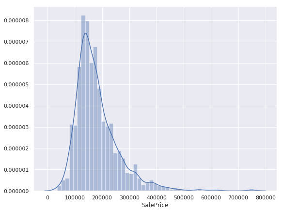

```python
sns.set(rc={'figure.figsize':(9,7)})
sns.distplot(train['SalePrice']);
```

### 6-1-3 Skewness vs Kurtosis

1. Skewness
   1. It is the degree of distortion from the symmetrical bell curve or the normal distribution. It measures the lack of symmetry in data distribution. It differentiates extreme values in one versus the other tail. A symmetrical distribution will have a skewness of 0.

[figure not shown]

2. Kurtosis
   1. Kurtosis is all about the tails of the distribution — not the peakedness or flatness. It is used to describe the extreme values in one versus the other tail. It is actually the measure of outliers present in the distribution.

```python
#skewness and kurtosis
print("Skewness: %f" % train['SalePrice'].skew())
print("Kurtosis: %f" % train['SalePrice'].kurt())
```

```
Skewness: 1.882876
Kurtosis: 6.536282
```

## 6-2 Visualization

**Data visualization** is the presentation of data in a pictorial or graphical format. It enables decision makers to see analytics presented visually, so they can grasp difficult concepts or identify new patterns.

With interactive visualization, you can take the concept a step further by using technology to drill down into charts and graphs for more detail, interactively changing what data you see and how it’s processed.[SAS]

In this section I show you **11 plots** with **matplotlib** and **seaborn** that is listed in the blew picture:

[figure not shown]

### 6-2-1 Scatter plot

Scatter plot Purpose To identify the type of relationship (if any) between two quantitative variables

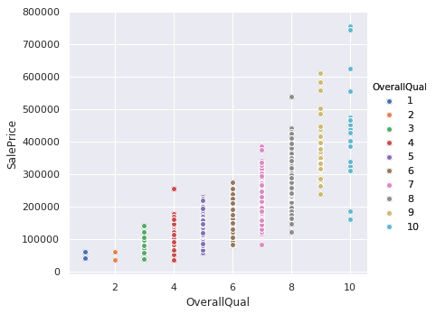

```python
# Modify the graph above by assigning each species an individual color.
columns = ['SalePrice','OverallQual','TotalBsmtSF','GrLivArea','GarageArea','FullBath','YearBuilt','YearRemodAdd']
g=sns.FacetGrid(train[columns], hue="OverallQual", size=5) \
   .map(plt.scatter, "OverallQual", "SalePrice") \
   .add_legend()
g=g.map(plt.scatter, "OverallQual", "SalePrice",edgecolor="w").add_legend();
plt.show()
```

### 6-2-2 Box

In descriptive statistics, a **box plot** or boxplot is a method for graphically depicting groups of numerical data through their quartiles. Box plots may also have lines extending vertically from the boxes (whiskers) indicating variability outside the upper and lower quartiles, hence the terms box-and-whisker plot and box-and-whisker diagram.[wikipedia]

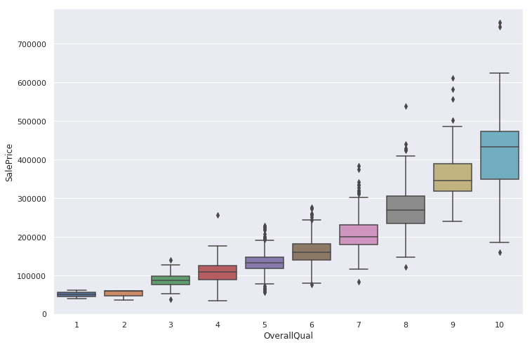

```python
data = pd.concat([train['SalePrice'], train['OverallQual']], axis=1)
f, ax = plt.subplots(figsize=(12, 8))
fig = sns.boxplot(x='OverallQual', y="SalePrice", data=data)
```

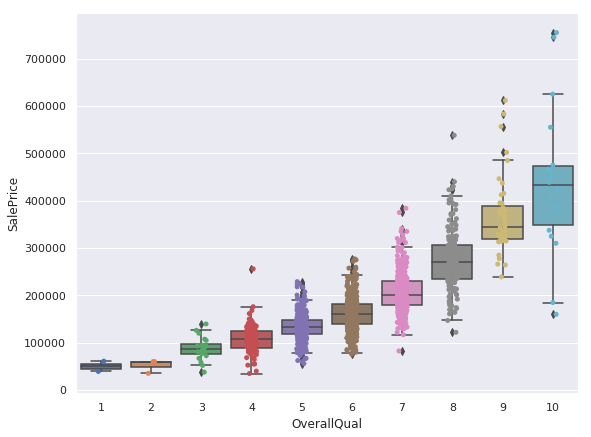

```python
ax= sns.boxplot(x="OverallQual", y="SalePrice", data=train[columns])
ax= sns.stripplot(x="OverallQual", y="SalePrice", data=train[columns], jitter=True, edgecolor="gray")
plt.show()
```

### 6-2-3 Histogram

We can also create a **histogram** of each input variable to get an idea of the distribution.

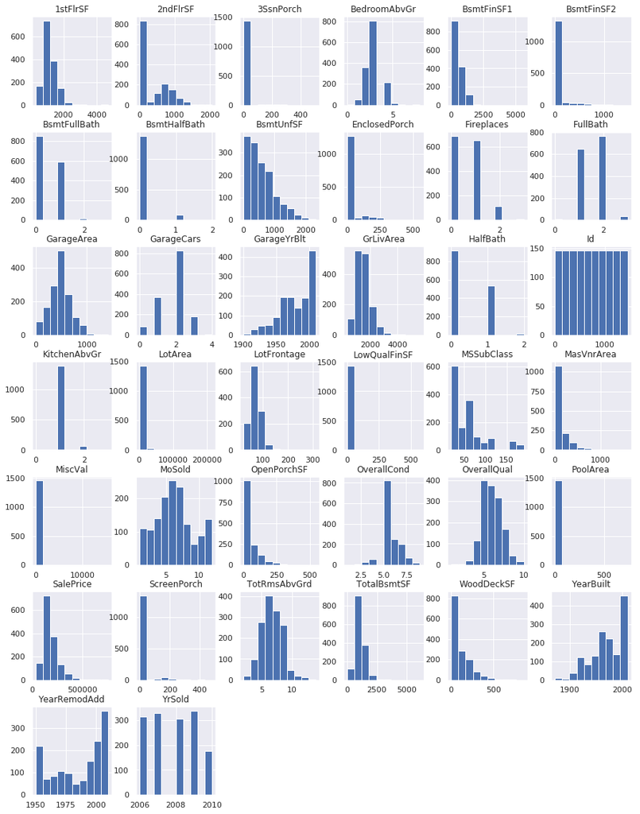

```python
# histograms
train.hist(figsize=(15,20))
plt.figure()
```

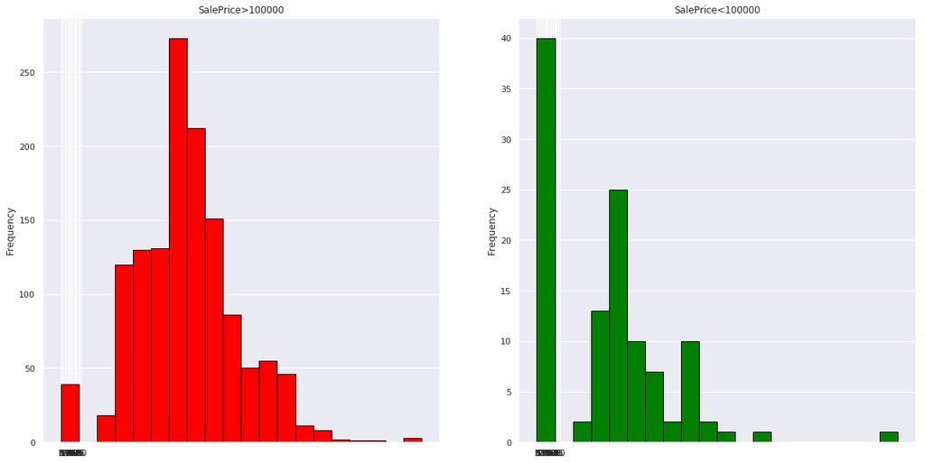

```python
mini_train=train[columns]
f,ax=plt.subplots(1,2,figsize=(20,10))
mini_train[mini_train['SalePrice']>100000].GarageArea.plot.hist(ax=ax[0],bins=20,edgecolor='black',color='red')
ax[0].set_title('SalePrice>100000')
x1=list(range(0,85,5))
ax[0].set_xticks(x1)
mini_train[mini_train['SalePrice']<100000].GarageArea.plot.hist(ax=ax[1],color='green',bins=20,edgecolor='black')
ax[1].set_title('SalePrice<100000')
x2=list(range(0,85,5))
ax[1].set_xticks(x2)
plt.show()
```

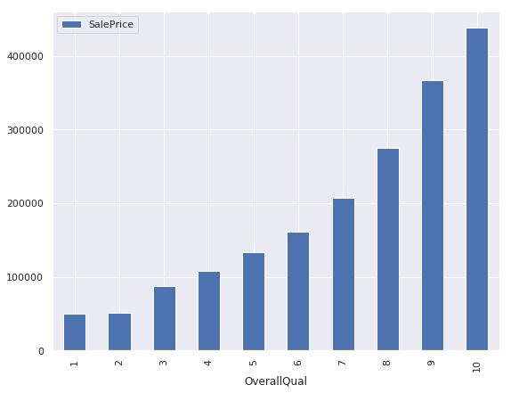

```python
mini_train[['SalePrice','OverallQual']].groupby(['OverallQual']).mean().plot.bar()
```

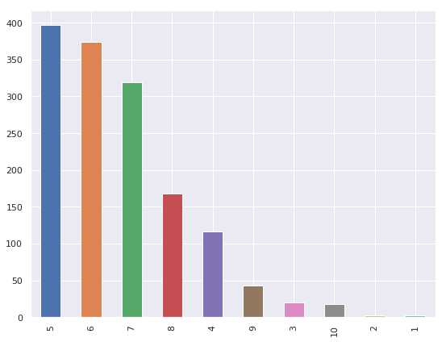

```python
train['OverallQual'].value_counts().plot(kind="bar");
```

It looks like perhaps two of the input variables have a Gaussian distribution. This is useful to note as we can use algorithms that can exploit this assumption.

### 6-2-4 Multivariate Plots

Now we can look at the interactions between the variables.

First, let’s look at scatterplots of all pairs of attributes. This can be helpful to spot structured relationships between input variables.

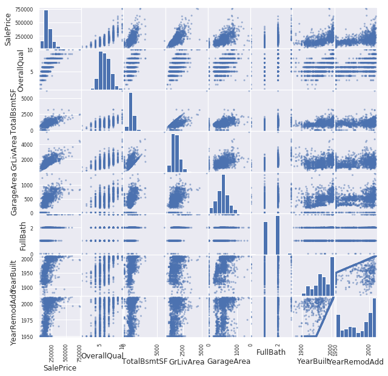

```python
# scatter plot matrix
pd.plotting.scatter_matrix(train[columns],figsize=(10,10))
plt.figure()
```

Note the diagonal grouping of some pairs of attributes. This suggests a high correlation and a predictable relationship.

### 6-2-5 violinplots

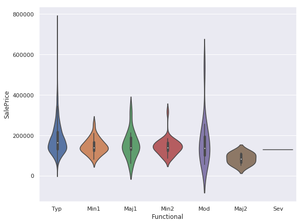

```python
# violinplots on petal-length for each species
sns.violinplot(data=train,x="Functional", y="SalePrice")
```

### 6-2-6 pairplot

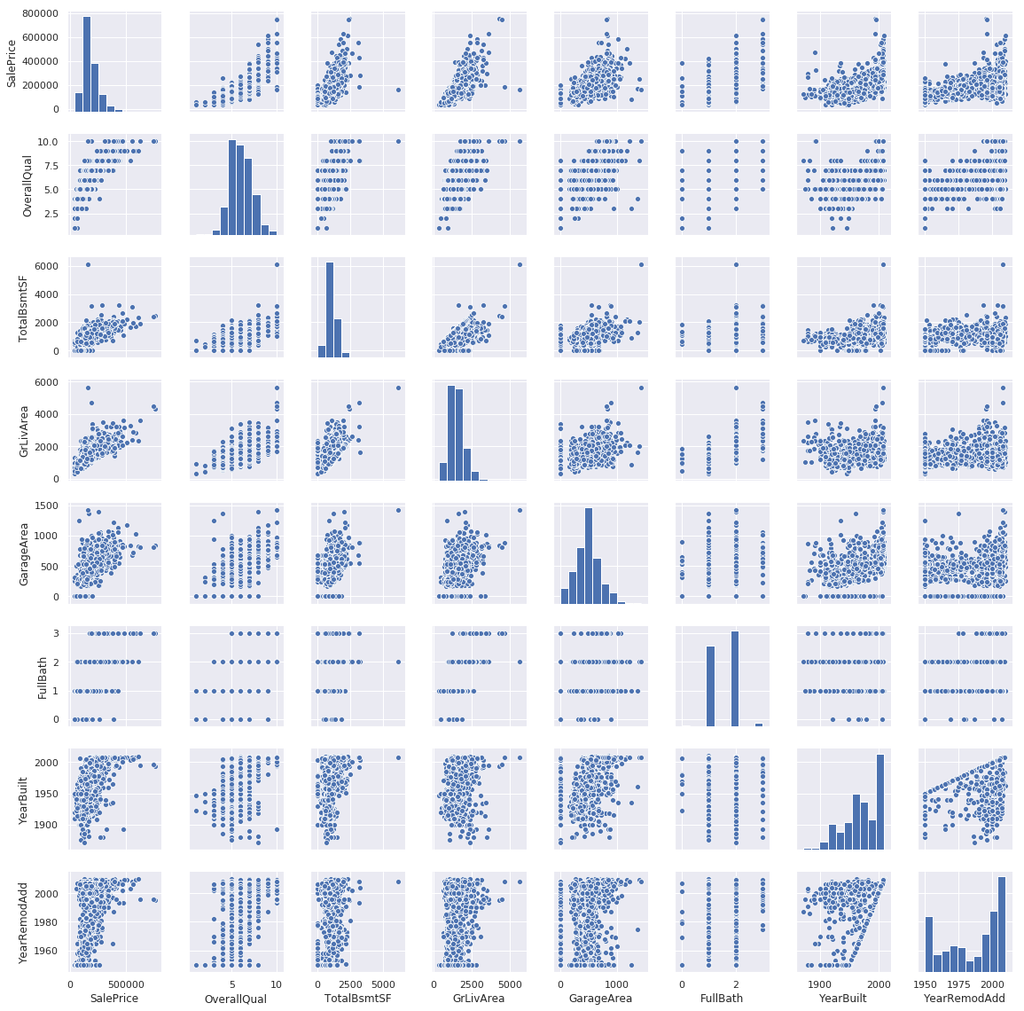

```python
# Using seaborn pairplot to see the bivariate relation between each pair of features
sns.set()
columns = ['SalePrice','OverallQual','TotalBsmtSF','GrLivArea','GarageArea','FullBath','YearBuilt','YearRemodAdd']
sns.pairplot(train[columns],size = 2 ,kind ='scatter')
plt.show()
```

### 6-2-7 kdeplot

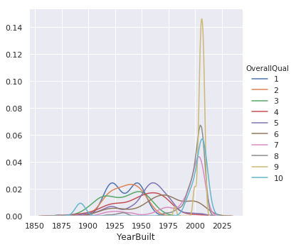

```python
# seaborn's kdeplot, plots univariate or bivariate density estimates.
#Size can be changed by tweeking the value used
columns = ['SalePrice','OverallQual','TotalBsmtSF','GrLivArea','GarageArea','FullBath','YearBuilt','YearRemodAdd']
sns.FacetGrid(train[columns], hue="OverallQual", size=5).map(sns.kdeplot, "YearBuilt").add_legend()
plt.show()
```

### 6-2-8 jointplot

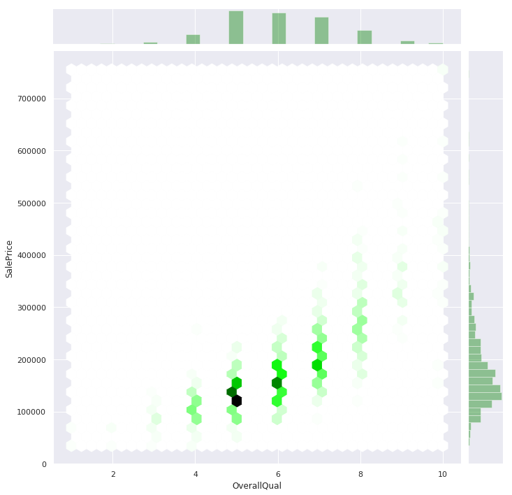

```python
# Use seaborn's jointplot to make a hexagonal bin plot
#Set desired size and ratio and choose a color.
columns = ['SalePrice','OverallQual','TotalBsmtSF','GrLivArea','GarageArea','FullBath','YearBuilt','YearRemodAdd']
sns.jointplot(x="OverallQual", y="SalePrice", data=train[columns], size=10,ratio=10, kind='hex',color='green')
plt.show()
```

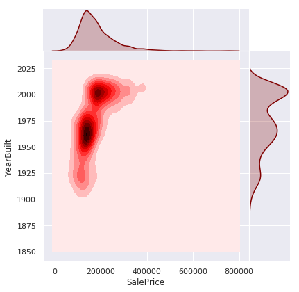

```python
# we will use seaborn jointplot shows bivariate scatterplots and univariate histograms with Kernel density
# estimation in the same figure
columns = ['SalePrice','OverallQual','TotalBsmtSF','GrLivArea','GarageArea','FullBath','YearBuilt','YearRemodAdd']
sns.jointplot(x="SalePrice", y="YearBuilt", data=train[columns], size=6, kind='kde', color='#800000', space=0)
```

### 6-2-9 Heatmap

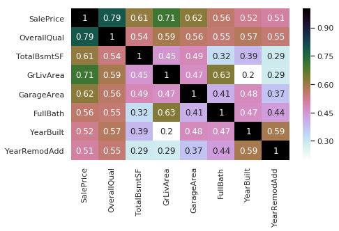

```python
plt.figure(figsize=(7,4))
columns = ['SalePrice','OverallQual','TotalBsmtSF','GrLivArea','GarageArea','FullBath','YearBuilt','YearRemodAdd']
sns.heatmap(train[columns].corr(),annot=True,cmap='cubehelix_r') #draws  heatmap with input as the correlation matrix calculted by(iris.corr())
plt.show()
```

### 6-2-10 radviz

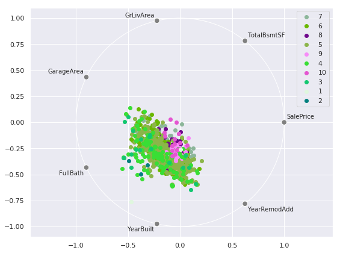

```python
from pandas.tools.plotting import radviz
columns = ['SalePrice','OverallQual','TotalBsmtSF','GrLivArea','GarageArea','FullBath','YearBuilt','YearRemodAdd']
radviz(train[columns], "OverallQual")
```

### 6-2-12 Factorplot

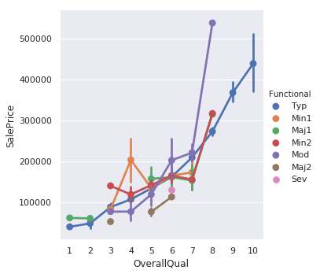

```python
sns.factorplot('OverallQual','SalePrice',hue='Functional',data=train)
plt.show()
```

## 6-3 Data Preprocessing

**Data preprocessing** refers to the transformations applied to our data before feeding it to the algorithm.

Data Preprocessing is a technique that is used to convert the raw data into a clean data set. In other words, whenever the data is gathered from different sources it is collected in raw format which is not feasible for the analysis. there are plenty of steps for data preprocessing and we just listed some of them :

1. removing Target column (id)
2. Sampling (without replacement)
3. Making part of iris unbalanced and balancing (with undersampling and SMOTE)
4. Introducing missing values and treating them (replacing by average values)
5. Noise filtering
6. Data discretization
7. Normalization and standardization
8. PCA analysis
9. Feature selection (filter, embedded, wrapper)

## 6-3-1 Noise filtering (Outliers)

An outlier is a data point that is distant from other similar points. Further simplifying an outlier is an observation that lies on abnormal observation amongst the normal observations in a sample set of population.

[figure not shown]

In statistics, an outlier is an observation point that is distant from other observations.

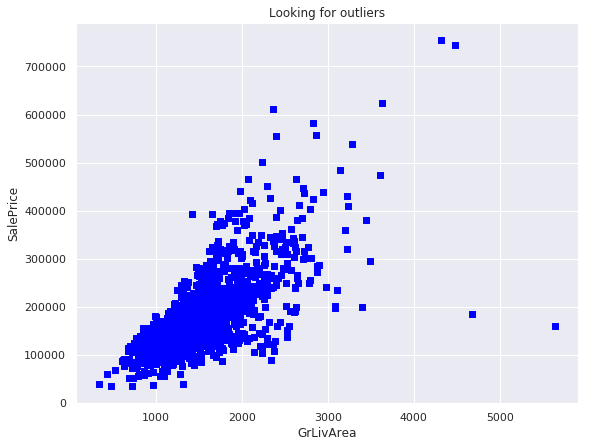

```python
# Looking for outliers, as indicated in https://ww2.amstat.org/publications/jse/v19n3/decock.pdf
plt.scatter(train.GrLivArea, train.SalePrice, c = "blue", marker = "s")
plt.title("Looking for outliers")
plt.xlabel("GrLivArea")
plt.ylabel("SalePrice")
plt.show()

train = train[train.GrLivArea < 4000]
```

2 extreme outliers on the bottom right

```python
#deleting points
train.sort_values(by = 'GrLivArea', ascending = False)[:2]
train = train.drop(train[train['Id'] == 1299].index)
train = train.drop(train[train['Id'] == 524].index)
```

```python
#log transform skewed numeric features:
numeric_feats = all_data.dtypes[all_data.dtypes != "object"].index
skewed_feats = train[numeric_feats].apply(lambda x: skew(x.dropna())) #compute skewness
skewed_feats = skewed_feats[skewed_feats > 0.75]
skewed_feats = skewed_feats.index

all_data[skewed_feats] = np.log1p(all_data[skewed_feats])
```

```python
all_data = pd.get_dummies(all_data)
```

```python
# Log transform the target for official scoring
#The key point is to to log_transform the numeric variables since most of them are skewed.
train.SalePrice = np.log1p(train.SalePrice)
y = train.SalePrice
```

Taking logs means that errors in predicting expensive houses and cheap houses will affect the result equally.

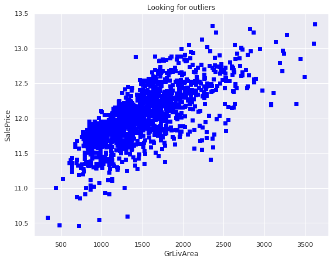

```python
plt.scatter(train.GrLivArea, train.SalePrice, c = "blue", marker = "s")
plt.title("Looking for outliers")
plt.xlabel("GrLivArea")
plt.ylabel("SalePrice")
plt.show()
```

## 6-4 Data Cleaning

When dealing with real-world data, dirty data is the norm rather than the exception. We continuously need to predict correct values, impute missing ones, and find links between various data artefacts such as schemas and records. We need to stop treating data cleaning as a piecemeal exercise (resolving different types of errors in isolation), and instead leverage all signals and resources (such as constraints, available statistics, and dictionaries) to accurately predict corrective actions.

## 6-4-1 Handle missing values

Firstly, understand that there is NO good way to deal with missing data

[figure not shown]

```python
#filling NA's with the mean of the column:
all_data = all_data.fillna(all_data.mean())
```

## 7- Model Deployment

In this section have been applied plenty of **learning algorithms** that play an important rule in your experiences and improve your knowledge in case of ML technique.

> **<< Note 3 >>** : The results shown here may be slightly different for your analysis because, for example, the neural network algorithms use random number generators for fixing the initial value of the weights (starting points) of the neural networks, which often result in obtaining slightly different (local minima) solutions each time you run the analysis. Also note that changing the seed for the random number generator used to create the train, test, and validation samples can change your results.

go to top

## 7-1 Families of ML algorithms

There are several categories for machine learning algorithms, below are some of these categories:

- Linear
  - Linear Regression
  - Logistic Regression
  - Support Vector Machines
- Tree-Based
  - Decision Tree
  - Random Forest
  - GBDT
- KNN
- Neural Networks

And if we want to categorize ML algorithms with the type of learning, there are below type:

- Classification
  - k-Nearest Neighbors
  - LinearRegression
  - SVM
  - DT
  - NN
- clustering
  - K-means
  - HCA
  - Expectation Maximization
- Visualization and dimensionality reduction:
  - Principal Component Analysis(PCA)
  - Kernel PCA
  - Locally -Linear Embedding (LLE)
  - t-distributed Stochastic Neighbor Embedding (t-SNE)
- Association rule learning
  - Apriori
  - Eclat
- Semisupervised learning
- Reinforcement Learning
  - Q-learning
- Batch learning & Online learning
- Ensemble Learning

**<< Note >>**

> Here is no method which outperforms all others for all tasks

## 7-2 Accuracy and precision

One of the most important questions to ask as a machine learning engineer when evaluating our model is how to judge our own model? each machine learning model is trying to solve a problem with a different objective using a different dataset and hence, it is important to understand the context before choosing a metric.

[figure not shown]

### 7-2-1 RMSE

Root-Mean-Squared-Error (RMSE) between the logarithm of the predicted value and the logarithm of the observed sales price. (Taking logs means that errors in predicting expensive houses and cheap houses will affect the result equally.)

[figure not shown]

go to top

```python
#creating matrices for sklearn:
X_train = all_data[:train.shape[0]]
X_test = all_data[train.shape[0]:]
y = train.SalePrice
```

```python
X_train.info()
```

```
<class 'pandas.core.frame.DataFrame'>
Int64Index: 1456 entries, 0 to 1455
Columns: 288 entries, MSSubClass to SaleCondition_Partial
dtypes: float64(25), int64(11), uint8(252)
memory usage: 779.2 KB
```

## 7-3 Ridge

```python
def rmse_cv(model):
    rmse= np.sqrt(-cross_val_score(model, X_train, y, scoring="neg_mean_squared_error", cv = 5))
    return(rmse)
```

```python
model_ridge = Ridge()
```

```python
alphas = [0.05, 0.1, 0.3, 1, 3, 5, 10, 15, 30, 50, 75]
cv_ridge = [rmse_cv(Ridge(alpha = alpha)).mean() for alpha in alphas]
```

## 7-3-1 Root Mean Squared Error

```
Text(0,0.5,'rmse')
```

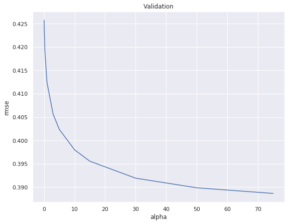

```python
cv_ridge = pd.Series(cv_ridge, index = alphas)
cv_ridge.plot(title = "Validation")
plt.xlabel("alpha")
plt.ylabel("rmse")
```

```python
# steps
steps = [('scaler', StandardScaler()),
         ('ridge', Ridge())]

# Create the pipeline: pipeline
pipeline = Pipeline(steps)

# Specify the hyperparameter space
parameters = {'ridge__alpha':np.logspace(-4, 0, 50)}

# Create the GridSearchCV object: cv
cv = GridSearchCV(pipeline, parameters, cv=3)

# Fit to the training set
cv.fit(X_train, y)

#predict on train set
y_pred_train=cv.predict(X_train)

# Predict test set
y_pred_test=cv.predict(X_test)

# rmse on train set
rmse = np.sqrt(mean_squared_error(y, y_pred_train))
print("Root Mean Squared Error: {}".format(rmse))
```

```
Root Mean Squared Error: 0.32811446712445086
```

A random forest is a meta estimator that fits a number of decision tree classifiers on various sub-samples of the dataset and uses averaging to improve the predictive accuracy and control over-fitting. The sub-sample size is always the same as the original input sample size but the samples are drawn with replacement if bootstrap=True (default).

```python
num_test = 0.3
X_train, X_test, y_train, y_test = train_test_split(X_train, y, test_size=num_test, random_state=100)
```

```python
# Fit Random Forest on Training Set
from sklearn.ensemble import RandomForestRegressor
regressor = RandomForestRegressor(n_estimators=300, random_state=0)
regressor.fit(X_train, y_train)

# Score model
regressor.score(X_train, y_train)
```

```
0.877294261920777
```

## 7-5 XGBoost

XGBoost is one of the most popular machine learning algorithm these days. Regardless of the type of prediction task at hand; regression or classification.

### 7-5-1 But what makes XGBoost so popular?

1. Speed and performance : Originally written in C++, it is comparatively faster than other ensemble classifiers.
2. Core algorithm is parallelizable : Because the core XGBoost algorithm is parallelizable it can harness the power of multi-core computers. It is also parallelizable onto GPU’s and across networks of computers making it feasible to train on very large datasets as well.
3. Consistently outperforms other algorithm methods : It has shown better performance on a variety of machine learning benchmark datasets.
4. Wide variety of tuning parameters : XGBoost internally has parameters for cross-validation, regularization, user-defined objective functions, missing values, tree parameters, scikit-learn compatible API etc.[10]

> XGBoost (Extreme Gradient Boosting) belongs to a family of boosting algorithms and uses the gradient boosting (GBM) framework at its core. It is an optimized distributed gradient boosting library. But wait, what is boosting? Well, keep on reading.

```python
# Initialize model
from xgboost.sklearn import XGBRegressor
XGB_Regressor = XGBRegressor()

# Fit the model on our data
XGB_Regressor.fit(X_train, y_train)
```

```
XGBRegressor(base_score=0.5, booster='gbtree', colsample_bylevel=1,
       colsample_bytree=1, gamma=0, learning_rate=0.1, max_delta_step=0,
       max_depth=3, min_child_weight=1, missing=None, n_estimators=100,
       n_jobs=1, nthread=None, objective='reg:linear', random_state=0,
       reg_alpha=0, reg_lambda=1, scale_pos_weight=1, seed=None,
       silent=True, subsample=1)
```

```python
# Score model
XGB_Regressor.score(X_train, y_train)
```

```
0.4598271920204544
```

## 7-6 LassoCV

Lasso linear model with iterative fitting along a regularization path. The best model is selected by cross-validation.

```python
lasso=LassoCV()
```

```python
# Fit the model on our data
lasso.fit(X_train, y_train)
```

```
LassoCV(alphas=None, copy_X=True, cv='warn', eps=0.001, fit_intercept=True,
    max_iter=1000, n_alphas=100, n_jobs=None, normalize=False,
    positive=False, precompute='auto', random_state=None,
    selection='cyclic', tol=0.0001, verbose=False)
```

```python
# Score model
lasso.score(X_train, y_train)
```

```
0.1171814974164107
```

## 7-7 GradientBoostingRegressor

GB builds an additive model in a forward stage-wise fashion; it allows for the optimization of arbitrary differentiable loss functions. In each stage a regression tree is fit on the negative gradient of the given loss function.

```python
boostingregressor=GradientBoostingRegressor()
```

```python
# Fit the model on our data
boostingregressor.fit(X_train, y_train)
```

```
GradientBoostingRegressor(alpha=0.9, criterion='friedman_mse', init=None,
             learning_rate=0.1, loss='ls', max_depth=3, max_features=None,
             max_leaf_nodes=None, min_impurity_decrease=0.0,
             min_impurity_split=None, min_samples_leaf=1,
             min_samples_split=2, min_weight_fraction_leaf=0.0,
             n_estimators=100, n_iter_no_change=None, presort='auto',
             random_state=None, subsample=1.0, tol=0.0001,
             validation_fraction=0.1, verbose=0, warm_start=False)
```

```python
# Score model
boostingregressor.score(X_train, y_train)
```

```
0.4931895744123065
```

## 7-8 DecisionTree

```python
from sklearn.tree import DecisionTreeRegressor

# Define model. Specify a number for random_state to ensure same results each run
dt = DecisionTreeRegressor(random_state=1)
```

```python
# Fit model
dt.fit(X_train, y_train)
```

```
DecisionTreeRegressor(criterion='mse', max_depth=None, max_features=None,
           max_leaf_nodes=None, min_impurity_decrease=0.0,
           min_impurity_split=None, min_samples_leaf=1,
           min_samples_split=2, min_weight_fraction_leaf=0.0,
           presort=False, random_state=1, splitter='best')
```

```python
dt.score(X_train, y_train)
```

```
0.9999999994606554
```

## 7-9 ExtraTreeRegressor

```python
from sklearn.tree import ExtraTreeRegressor

dtr = ExtraTreeRegressor()
```

```python
# Fit model
dtr.fit(X_train, y_train)
```

```
ExtraTreeRegressor(criterion='mse', max_depth=None, max_features='auto',
          max_leaf_nodes=None, min_impurity_decrease=0.0,
          min_impurity_split=None, min_samples_leaf=1, min_samples_split=2,
          min_weight_fraction_leaf=0.0, random_state=None,
          splitter='random')
```

```python
# Fit model
dtr.score(X_train, y_train)
```

```
0.999999998257654
```

## 8- Conclusion

This kernel is not completed yet, I will try to cover all the parts related to the process of ML with a variety of Python packages and I know that there are still some problems then I hope to get your feedback to improve it.

You can follow me on:

###### [GitHub](https://github.com/mjbahmani)

**I hope you find this kernel helpful and some **UPVOTES** would be very much appreciated**

# 9- References

1. [Https://skymind.ai/wiki/machine-learning-workflow](https://skymind.ai/wiki/machine-learning-workflow)
2. [Problem-define](https://machinelearningmastery.com/machine-learning-in-python-step-by-step/)
3. [Sklearn](http://scikit-learn.org/)
4. [Machine-learning-in-python-step-by-step](https://machinelearningmastery.com/machine-learning-in-python-step-by-step/)
5. [Data Cleaning](http://wp.sigmod.org/?p=2288)
6. [Kaggle kernel](https://www.kaggle.com/serigne/stacked-regressions-top-4-on-leaderboard)
7. [Choosing-the-right-metric-for-machine-learning-models-part](https://medium.com/usf-msds/choosing-the-right-metric-for-machine-learning-models-part-1-a99d7d7414e4)
8. [Unboxing outliers in machine learning](https://medium.com/datadriveninvestor/unboxing-outliers-in-machine-learning-d43fe40d88a6)
9. [How to handle missing data](https://towardsdatascience.com/how-to-handle-missing-data-8646b18db0d4)
10. [Datacamp](https://www.datacamp.com/community/tutorials/xgboost-in-python)

Go to first step: [**Course Home Page**](https://www.kaggle.com/mjbahmani/10-steps-to-become-a-data-scientist)

Go to next step : [**Titanic**](https://www.kaggle.com/mjbahmani/a-comprehensive-ml-workflow-with-python)